# Unidad 2 – Realce y Restauración de Imágenes

Published

September 2, 2026

## 1 Fin de aprendizaje

- Aplicar técnicas de mejora y restauración de imágenes digitales.
- Utilizar operaciones matriciales y filtros en OpenCV.
- Comprender fundamentos matemáticos de histogramas y filtrado.
- Preparar imágenes para tareas avanzadas de análisis visual.

## 2 Introducción

- El realce mejora la apariencia **visual** de las imágenes.
- Facilita tareas como:
  - Detección de objetos
  - Reconocimiento de texturas (ej. imágenes médicas)
  - Segmentación y clasificación

## 3 Descomposición en canales RGB

- Una imagen en color puede verse como **tres matrices en escala de grises**:
  - **Canal R (Rojo)**
  - **Canal G (Verde)**
  - **Canal B (Azul)**
- Cada canal almacena intensidades entre 0 y 255.
- La combinación de los tres forma la imagen en color.

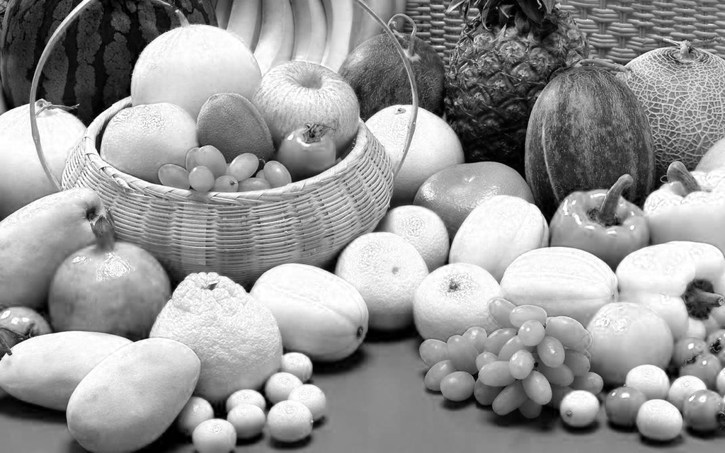

Canal R

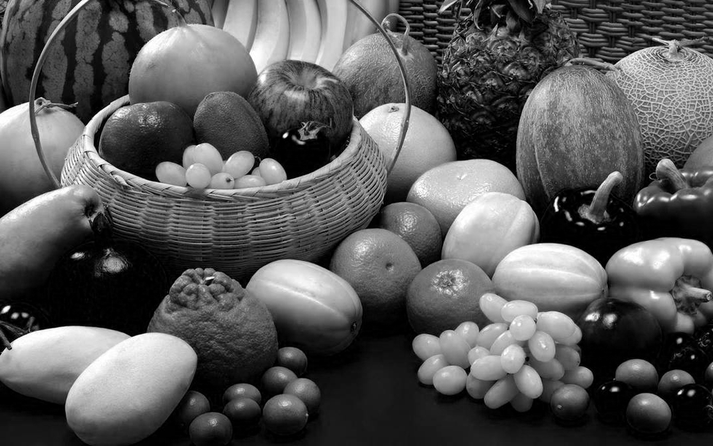

Canal G

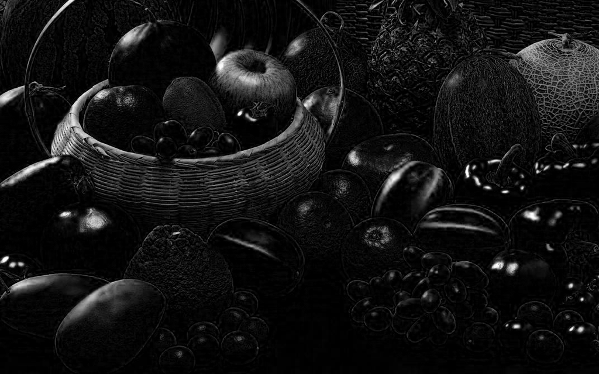

Canal B

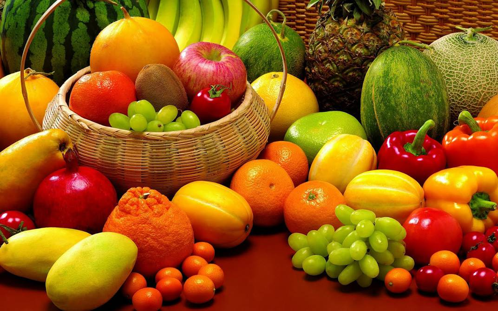

Imagen combinada

## 4 Representación de imágenes

- Una imagen digital en escala de grises puede representarse como una **matriz** $I$ de tamaño $M \times N$:

$$I = \begin{bmatrix}
i_{11} & i_{12} & \cdots & i_{1N} \\
i_{21} & i_{22} & \cdots & i_{2N} \\
\vdots & \vdots & \ddots & \vdots \\
i_{M1} & i_{M2} & \cdots & i_{MN}
\end{bmatrix}$$

- Cada elemento $i_{mn}$ es un valor de **intensidad** (0–255 en imágenes de 8 bits).

## 5 Visualización de un patch en RGB y sus canales

**Canal R**  
[[171 137 145 137 130] [151 137 136 123 105] [142 158 154 141 112] [160 182 157 141 114] [173 170 122 106 99]]  
**Canal G**  
[[124 94 105 105 104] [104 94 99 91 82] [ 97 117 119 111 89] [118 143 125 114 93] [132 134 91 81 80]]  
**Canal B**  
[[70 41 53 54 55] [50 39 46 40 32] [40 61 65 57 37] [60 86 68 59 40] [76 76 34 25 24]]  
**Juntos**  
[[[171 124 70] [137 94 41] [145 105 53] [137 105 54] [130 104 55]]

[[151 104 50] [137 94 39] [136 99 46] [123 91 40] [105 82 32]]

[[142 97 40] [158 117 61] [154 119 65] [141 111 57] [112 89 37]]

[[160 118 60] [182 143 86] [157 125 68] [141 114 59] [114 93 40]]

[[173 132 76] [170 134 76] [122 91 34] [106 81 25] [ 99 80 24]]]

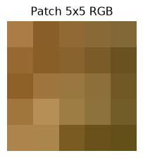

```python
import cv2
import matplotlib.pyplot as plt
import numpy as np
from IPython.display import display, Markdown

# Cargar imagen en color (OpenCV usa BGR)
img_bgr = cv2.imread("imagenes/frutas.jpg", cv2.IMREAD_COLOR)
img_rgb = cv2.cvtColor(img_bgr, cv2.COLOR_BGR2RGB)

# Seleccionar un patch pequeño (5x5 píxeles)
patch = img_rgb[0:5, 0:5, :]

# Separar los canales
R = patch[:,:,0]
G = patch[:,:,1]
B = patch[:,:,2]

# Mostrar el patch en color y guardarlo
plt.figure(figsize=(2.5,2.5))
plt.imshow(patch)
plt.axis('off')
plt.title("Patch 5x5 RGB")
plt.savefig("patch_rgb.png", bbox_inches="tight")
plt.close()

# Convertir las matrices a strings
R_str = np.array2string(R, max_line_width=40)
G_str = np.array2string(G, max_line_width=40)
B_str = np.array2string(B, max_line_width=40)
# Mostrar en formato columnas
display(Markdown(f"""
<div style="display:flex; gap:25px;">
<div style="font-size:15px; white-space:pre;">
<b>Canal R</b><br>{R_str}<br><br>
<b>Canal G</b><br>{G_str}<br><br>
<b>Canal B</b><br>{B_str}<br><br>
<b>Juntos</b><br>{patch}
</div>
<div style="flex:1; text-align:center;">
<img src='patch_rgb.png' style="width:100%; height:auto;">
</div>

</div>
"""))
```

## 6 Mezcla aditiva de colores – Modelo RGB

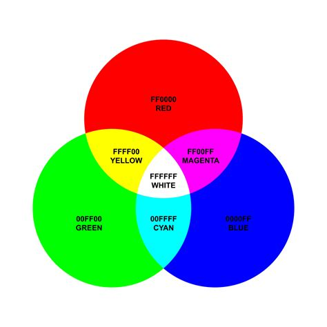

RGB color model venn diagram

**Explicación:**

- El modelo **RGB** (Red, Green, Blue) es **aditivo**.
- Combinaciones:
  - Rojo + Verde = Amarillo
  - Verde + Azul = Cian
  - Azul + Rojo = Magenta
  - Rojo + Verde + Azul (máxima intensidad) = Blanco
- Cada canal varía de **0 a 255**, permitiendo representar millones de colores.
- Es el modelo usado en **pantallas, cámaras y procesamiento digital de imágenes**.

## 7 Visualización de valores en escala de grises

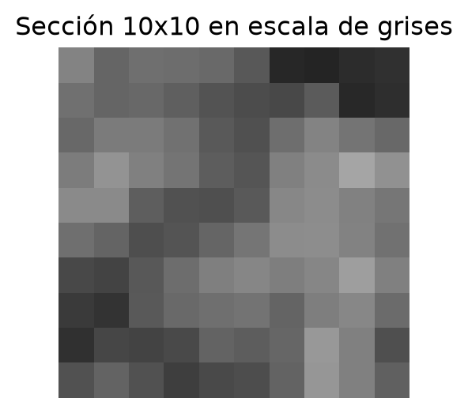

```
[[132 101 111 109 106  88  39  37  45  48]
 [112 101 104  95  83  76  72  91  41  46]
 [104 123 123 114  90  80 110 131 116 104]
 [124 148 128 116  93  85 128 139 165 145]
 [138 138  94  82  79  89 135 140 129 118]
 [111 100  78  84 101 117 140 141 130 114]
 [ 72  67  88 109 127 134 126 134 158 128]
 [ 58  51  90 105 111 115 100 126 135 107]
 [ 49  70  67  74  99  93 102 152 128  79]
 [ 82  99  81  62  73  77  99 150 128  96]]
```

```python
import cv2
import matplotlib.pyplot as plt
import numpy as np

# Cargar imagen en escala de grises
img = cv2.imread("imagenes/frutas.jpg", cv2.IMREAD_GRAYSCALE)

# Seleccionar una sección pequeña (ej. 10x10 píxeles desde la esquina superior izquierda)
patch = img[0:10, 0:10]

# Mostrar la sección ampliada como imagen
plt.figure(figsize=(3,3))
plt.imshow(patch, cmap='gray', vmin=0, vmax=255)
plt.title("Sección 10x10 en escala de grises")
plt.axis('off')
plt.show()

# Convertir la matriz a string
matriz_str = np.array2string(patch, max_line_width=80)

# Mostrar en formato markdown con letra pequeña
from IPython.display import display, Markdown
display(Markdown(f"<pre style='font-size:15px'>{matriz_str}</pre>"))
```

## 8 Histograma de una imagen

- El histograma es la **frecuencia de aparición de intensidades**.
- Formalmente:

$$h(r_k) = n_k$$

donde $r_k$ es un nivel de gris y $n_k$ el número de píxeles con ese valor.

### 8.1 Código: Construcción del histograma

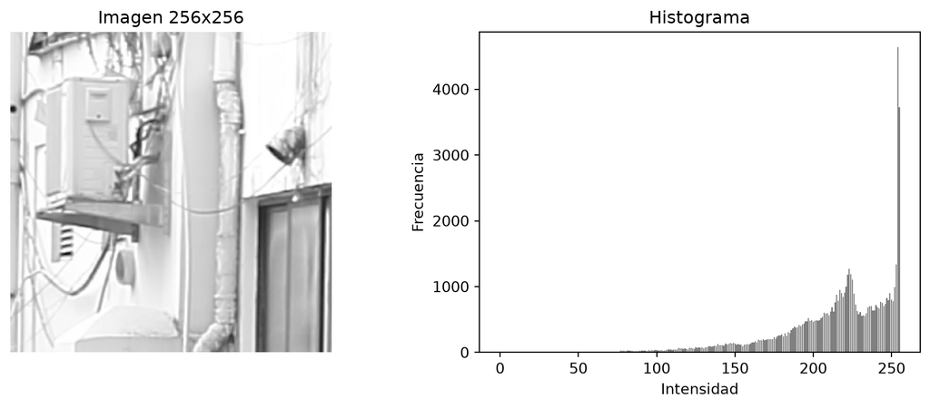

```python
import cv2
import numpy as np
import matplotlib.pyplot as plt

# Cargar imagen en escala de grises
img = cv2.imread( "imagenes/DPP0357.TIF", cv2.IMREAD_GRAYSCALE)
crop = img[:256, :256]

# Calcular histograma con OpenCV
hist = cv2.calcHist([crop], [0], None, [256], [0,256])

# Crear una figura con dos subplots lado a lado
plt.figure(figsize=(12,4))
plt.subplot(1,2,1)
plt.imshow(crop, cmap='gray')
plt.title("Imagen 256x256")
plt.axis('off')

plt.subplot(1,2,2)
plt.bar(np.arange(256), hist.flatten(), color='gray')
plt.title("Histograma")
plt.xlabel("Intensidad")
plt.ylabel("Frecuencia")
plt.show()
```

## 9 Ecualización de histograma

- Busca redistribuir los niveles de gris para mejorar el contraste.
- Función de transformación acumulativa:

$$s_k = (L-1)\sum_{j=0}^k \frac{n_j}{MN}$$

donde:  
- $L$ = número de niveles (256 en 8 bits).  
- $M \times N$ = número total de píxeles.

## 10 Ejemplo de ecualización de histograma

Consideremos una imagen de

$$M \times N = 8$$

píxeles, con intensidades de 3 bits  
($L = 8$ niveles, de 0 a 7):

$$I = [3, 3, 4, 5, 6, 6, 6, 7]$$

1. Histograma de frecuencias

| Intensidad ($r_k$) | Frecuencia ($n_k$) |
| --- | --- |
| 0 | 0 |
| 1 | 0 |
| 2 | 0 |
| 3 | 2 |
| 4 | 1 |
| 5 | 1 |
| 6 | 3 |
| 7 | 1 |

### 10.1 2. Probabilidades y acumuladas

Probabilidad: $p(r_k) = n_k / 8$

| $r_k$ | $p(r_k)$ | CDF $\sum_{j=0}^k p(r_j)$ |
| --- | --- | --- |
| 3 | 0.25 | 0.25 |
| 4 | 0.125 | 0.375 |
| 5 | 0.125 | 0.500 |
| 6 | 0.375 | 0.875 |
| 7 | 0.125 | 1.000 |

### 10.2 3. Nueva asignación de intensidades

$$s_k = (L-1)\sum_{j=0}^k p(r_j)$$

Con $L-1 = 7$:

| $r_k$ | CDF | $s_k$ |
| --- | --- | --- |
| 3 | 0.25 | $7 \cdot 0.25 = 1.75 \approx 2$ |
| 4 | 0.375 | $7 \cdot 0.375 = 2.63 \approx 3$ |
| 5 | 0.50 | $7 \cdot 0.50 = 3.50 \approx 4$ |
| 6 | 0.875 | $7 \cdot 0.875 = 6.13 \approx 6$ |
| 7 | 1.00 | $7 \cdot 1.00 = 7.00$ |

### 10.3 4. Imagen ecualizada

Imagen original:
$$[3, 3, 4, 5, 6, 6, 6, 7]$$

Imagen ecualizada:
$$[2, 2, 3, 4, 6, 6, 6, 7]$$

**Conclusión:** La ecualización redistribuyó los valores, extendiendo mejor el contraste entre 2 y 7.

### 10.4 Código: Ecualización con OpenCV

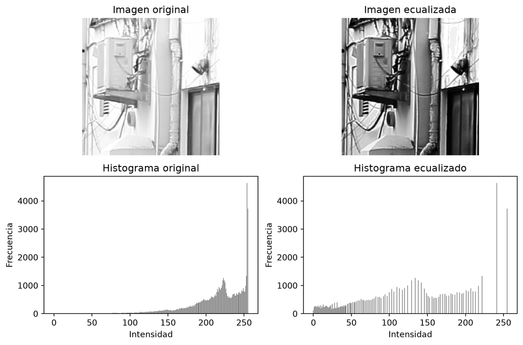

```python
# Ecualización de histograma
eq = cv2.equalizeHist(crop)

# Calcular histogramas
hist_orig = cv2.calcHist([crop], [0], None, [256], [0,256])
hist_eq = cv2.calcHist([eq], [0], None, [256], [0,256])

# Mostrar comparación
plt.figure(figsize=(9,6))

# Imagen original y su histograma
plt.subplot(2,2,1)
plt.imshow(crop, cmap='gray')
plt.title("Imagen original")
plt.axis('off')

plt.subplot(2,2,3)
plt.bar(np.arange(256), hist_orig.flatten(), color='gray')
plt.title("Histograma original")
plt.xlabel("Intensidad")
plt.ylabel("Frecuencia")

# Imagen ecualizada y su histograma
plt.subplot(2,2,2)
plt.imshow(eq, cmap='gray')
plt.title("Imagen ecualizada")
plt.axis('off')

plt.subplot(2,2,4)
plt.bar(np.arange(256), hist_eq.flatten(), color='gray')
plt.title("Histograma ecualizado")
plt.xlabel("Intensidad")
plt.ylabel("Frecuencia")

plt.tight_layout()
plt.show()
```

## 11 Convolución en imágenes

- La **convolución** es la operación matemática que permite aplicar un **kernel** o **máscara** sobre una imagen.
- Cada píxel resultante se obtiene como combinación ponderada de sus vecinos:

$$g(x,y) = \sum_{s=-a}^{a} \sum_{t=-b}^{b} H(s,t) \cdot f(x+s, y+t)$$

- Donde:
  - $f(x,y)$ = imagen original
  - $g(x,y)$ = imagen filtrada
  - $H$ = kernel o máscara (ej. 3x3, 5x5)
- Es la **base de los filtros espaciales**:
  - Suavizado
  - Realce de bordes
  - Detección de patrones

## 12 Filtrado espacial

- Consiste en aplicar una **máscara o kernel** $H$ a la imagen:

$$g(x,y) = \sum_{s=-a}^{a} \sum_{t=-b}^{b} H(s,t) \cdot f(x+s, y+t)$$

- Donde:
  - $f(x,y)$ = imagen original
  - $g(x,y)$ = imagen filtrada
  - $H$ = kernel de tamaño $(2a+1) \times (2b+1)$

### 12.1 Ejemplo de kernel promedio 3x3

$$H = \frac{1}{9}
\begin{bmatrix}
1 & 1 & 1 \\
1 & 1 & 1 \\
1 & 1 & 1
\end{bmatrix}$$

## 13 Filtro Promedio (Blur)

- El valor del píxel se reemplaza por el **promedio aritmético** de los píxeles en una ventana $k \times k$.

$$g(x,y) = \frac{1}{k^2} \sum_{s=-a}^{a} \sum_{t=-b}^{b} f(x+s, y+t)$$

- Kernel:

$$H = \frac{1}{k^2}
\begin{bmatrix}
1 & 1 & \cdots & 1 \\
1 & 1 & \cdots & 1 \\
\vdots & \vdots & \ddots & \vdots \\
1 & 1 & \cdots & 1
\end{bmatrix}$$

## 14 Ejemplo paso a paso

> Descargar ejemplo de kernels en Excel

Imagen local (parche 3x3):

$$\begin{bmatrix}
10 & 20 & 30 \\
40 & 50 & 60 \\
70 & 80 & 90
\end{bmatrix}$$

Kernel de suavizado:

$$\frac{1}{9}
\begin{bmatrix}
1 & 1 & 1 \\
1 & 1 & 1 \\
1 & 1 & 1
\end{bmatrix}$$

Resultado para el píxel central = $\tfrac{1}{9}(10+20+\cdots+90)=50$.

## 15 ¿Qué pasa en los bordes?

- Al aplicar un kernel, algunos vecinos quedan **fuera de la imagen**.
- Estrategias comunes de relleno (*padding*):
  - **Zero padding**: rellena con ceros.
  - **Replicate padding**: repite el valor de la orilla.
  - **Reflect padding**: refleja los valores como en un espejo.
  - **Valid convolution**: solo se calculan píxeles donde el kernel cabe completo.

### 15.1 Ejemplo en OpenCV

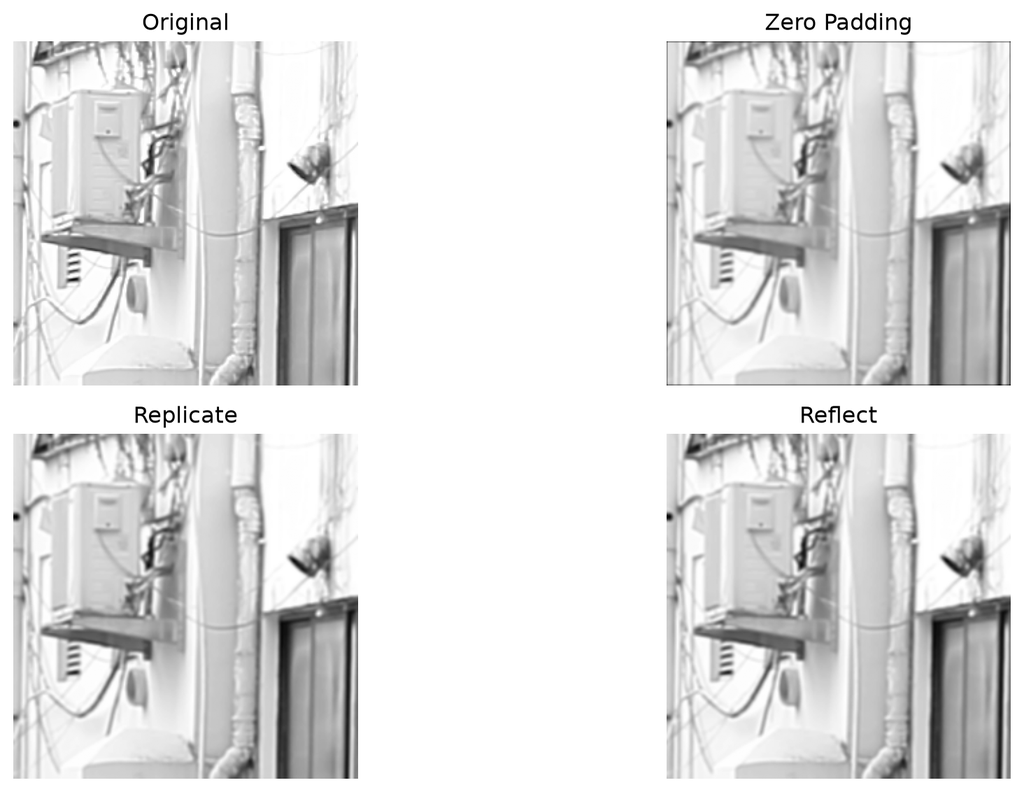

```python
import cv2
import matplotlib.pyplot as plt
import numpy as np

# Cargar imagen en escala de grises
#img = cv2.imread("imagenes/frutas.jpg", cv2.IMREAD_GRAYSCALE)
crop = img[:256,:256]

# Kernel promedio 3x3
kernel = np.ones((3,3), np.float32) / 9

# Distintos modos de borde
res_zero = cv2.filter2D(crop, -1, kernel, borderType=cv2.BORDER_CONSTANT)   # cero
res_replicate = cv2.filter2D(crop, -1, kernel, borderType=cv2.BORDER_REPLICATE)
res_reflect = cv2.filter2D(crop, -1, kernel, borderType=cv2.BORDER_REFLECT)

# Mostrar resultados
titles = ["Original", "Zero Padding", "Replicate", "Reflect"]
images = [crop, res_zero, res_replicate, res_reflect]

plt.figure(figsize=(12,6))
for i, (im, title) in enumerate(zip(images, titles)):
    plt.subplot(2,2,i+1)
    plt.imshow(im, cmap='gray')
    plt.title(title)
    plt.axis('off')
plt.tight_layout()
plt.show()
```

## 16 Filtro Gaussiano

- Utiliza una función **Gaussiana bidimensional** como kernel.

$$G(s,t) = \frac{1}{2\pi\sigma^2} \exp\left(-\frac{s^2+t^2}{2\sigma^2}\right)$$

- Operación de filtrado:

$$g(x,y) = \sum_{s=-a}^{a} \sum_{t=-b}^{b} G(s,t)\, f(x+s, y+t)$$

- Normalizado:

$$\sum_{s,t} G(s,t) = 1$$

## 17 Filtro de Mediana

- Es un método **no lineal**.
- En una ventana $k \times k$, reemplaza el valor del píxel por la **mediana** de los valores en esa ventana.

$$g(x,y) = \operatorname{mediana}\{ f(x+s, y+t) \mid -a \leq s,t \leq a \}$$

- Preserva bordes mejor que los filtros lineales.
- Muy eficaz contra ruido impulsivo (“sal y pimienta”).

## 18 Resumen Comparativo

| Filtro | Fórmula | Naturaleza | Ventajas | Desventajas |
| --- | --- | --- | --- | --- |
| **Promedio (Blur)** | Promedio aritmético | Lineal | Simple, rápido | Borra bordes y detalles |
| **Gaussiano** | Ponderación con distribución normal | Lineal | Suavizado natural, controlado por $\sigma$ | Más costoso computacionalmente |
| **Mediana** | Mediana de intensidades | No lineal | Preserva bordes, elimina ruido impulsivo | Menos eficiente en ventanas grandes |

### 18.1 Código: Filtros en OpenCV

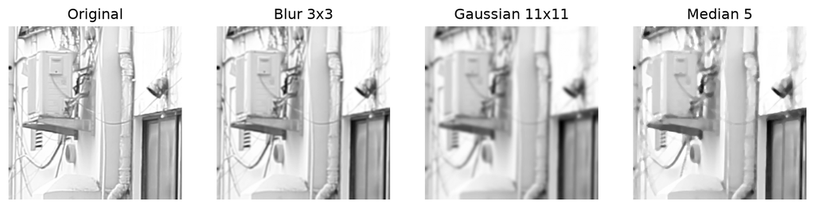

```python
# Filtros espaciales
blur3 = cv2.blur(crop, (3,3))
gauss11 = cv2.GaussianBlur(crop, (11,11), 0)
median5 = cv2.medianBlur(crop, 5)

# Mostrar resultados
titles = ["Original", "Blur 3x3", "Gaussian 11x11", "Median 5"]
images = [crop, blur3, gauss11, median5]

plt.figure(figsize=(12,4))
for i, (img, title) in enumerate(zip(images, titles)):
    plt.subplot(1,4,i+1)
    plt.imshow(img, cmap='gray')
    plt.title(title)
    plt.axis('off')
plt.show()
```

## 19 Comparación visual y análisis

- El filtro **blur** suaviza pero genera pérdida de detalle.
- El filtro **gaussiano** suaviza de forma más natural.
- El filtro **mediana** elimina ruido tipo “sal y pimienta” y preserva bordes.

## 20 Aprende

Consulta y toma notas de los siguientes materiales:

- Peguero Núñez, P. D. [Realce y restauración de imágenes](https://www.lpi.tel.uva.es/muitic/pim/docus/Realce_y_restauracion.pdf)
- Giménez-Palomares, F. et al. (2016). [Convolución y filtrado de imágenes](https://polipapers.upv.es/index.php/MSEL/article/download/4524/4724)
- León-Batallas, A. et al. (2020). [Revisión de métricas](https://recimundo.com/index.php/es/article/view/874/1372)
- Mazet, V. (2021). [Histogram transformations](https://vincmazet.github.io/bip/digital-images/transformations.html)
- Mazet, V. (2021). [Filtering](https://vincmazet.github.io/bip/digital-images/filtering.html)
- OpenCV. (s.f.). [Operaciones aritméticas](https://docs.opencv.org/3.4/d0/d86/tutorial_py_image_arithmetics.html)

## 21 Conclusión

- El **histograma** describe la distribución de intensidades.
- La **ecualización** mejora el contraste redistribuyendo los niveles.
- Los **filtros espaciales** suavizan o reducen ruido:
  - Media → suaviza más, pero pierde bordes.
  - Gaussiano → transición suave, natural.
  - Mediana → preserva bordes, elimina ruido impulsivo.
- Comprender la **matemática de matrices y convolución** es clave para usar y diseñar filtros.